```python
# ====================================================================
# Developer Utility: Module Auto-Reloading
# --------------------------------------------------------------------
# Uncomment the lines below if you are actively modifying the underlying
# pi-metaboqc source code. It ensures that changes in .py files are
# dynamically reloaded without restarting the Jupyter kernel.
# ====================================================================

%load_ext autoreload
%autoreload 2
```

# ${\pi}$-metaboqc: Interactive Analytical Workflow

This notebook provides an interactive, step-by-step execution of the `pi-metaboqc` metabolomics quality-control (QC) pipeline.

Execute the cells in order to inspect the intermediate `MetaboInt` matrices, their carried-forward metadata and metrics, and the quality-assessment (QA) diagnostics that document each decision.

## Step 00: Environment Initialization

Initializes the package, creates the root output directory, loads the validated TOML configuration, and reads the metadata and intensity tables. Each downstream processing or QA stage writes its own traceable subdirectory.

### Runtime parameter overrides

Each `run_*` method accepts its stage configuration as named keyword arguments and returns a `StageResult`. Its `.data` attribute contains the primary matrix or diagnostic payload, while `.metrics`, `.candidates`, and `.metadata` retain stage-specific audit information. A supplied value takes precedence over the TOML/JSON configuration, which itself takes precedence over the built-in default. For example: `correction_result = sc_engine.run_signal_correction(output_dir=step3_dir, base_est="QC-RLSC", loess_span=0.4)`.

```python
import os
from datetime import datetime
from importlib.resources import files
import pandas as pd
from loguru import logger

import pimqc
from pimqc.io import ensure_directory, load_pipeline_config
from pimqc.reporting import ReportInput
from pimqc.processing.stage import StageResult
from pimqc.reporting import utils as ru
from pimqc import (
    build_dataset,
    MetaboIntAssessor,
    MetaboIntFilter,
    MetaboIntCorrector,
    MetaboIntImputer,
    MetaboIntNormalizer,
)

logger.info(f"pimqc.__version__: {pimqc.__version__}")
pimqc.init(check_hardware=False, log_level="INFO", show_progress=True)

logger.info("Step 00: Environment Initialization...")


# Define standard directories
DATA_DIR = str(files("pimqc") / "resources" / "demo")
OUTPUT_DIR = os.path.join(".", "tutorial_output")
ensure_directory(OUTPUT_DIR)

# Load pipeline parameters
PARAMS_PATH = os.path.join(DATA_DIR, "pipeline_parameters.toml")
params = load_pipeline_config(str(PARAMS_PATH))

# Keep the same explicit state containers as run_pipeline.
stage_results = {}
assessments = {}
stage_tables = {}

# Load raw matrices
meta_df = pd.read_csv(os.path.join(DATA_DIR, "project_meta.csv"), header=[0])
int_df = pd.read_csv(
    os.path.join(DATA_DIR, "project_intensity.csv"), index_col=[0], header=[0]
)
```

```
2026-08-19 14:42:03.640 | INFO     | __main__:<module>:21 - pimqc.__version__: 1.3.1
```

```
2026-08-19 14:42:03.642 | INFO     | __main__:<module>:24 - Step 00: Environment Initialization...
2026-08-19 14:42:03.647 | SUCCESS  | config:load_pipeline_config:70 - Pipeline configuration loaded and validated.
2026-08-19 14:42:03.647 | SUCCESS  | config:load_pipeline_config:70 - Pipeline configuration loaded and validated.
```

## Step 01: Raw Dataset Construction

Validates and aligns the raw intensity table with metadata, resolves duplicate features, samples, and injection-order issues, and constructs a MultiIndex-backed `MetaboInt` object. Sample type, batch, injection order, and optional biological-group metadata are carried forward; explicit zero intensities are converted to missing values.

```
2026-08-19 14:42:03.923 | INFO     | __main__:<module>:1 - Step 01: Dataset Construction...
2026-08-19 14:42:04.038 | INFO     | builder:execute_build:406 - MetaboInt raw dataset saved as: .\tutorial_output\01_Raw_Data\Raw_Data_Intensity.csv
2026-08-19 14:42:04.039 | INFO     | builder:execute_build:423 - MetaboInt object built: 376 metabolites, 466 samples.
2026-08-19 14:42:04.040 | INFO     | builder:_audit_dataset_health:261 - Executing dataset health audit...
2026-08-19 14:42:04.042 | INFO     | builder:_audit_dataset_health:288 - [Audit] No Outlier Reference Features (ORF) detected. This is normal for untargeted datasets; ORF diagnostics will be skipped.
```

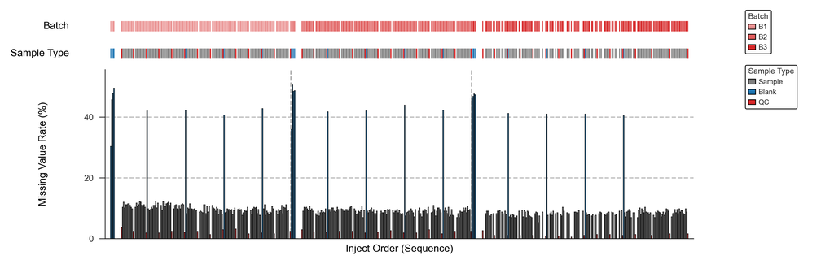

```
2026-08-19 14:42:05.605 | INFO     | builder:_render_dataset_dashboard:481 - Global acquisition overview plot saved as: tutorial_output\01_Raw_Data\Global_Acquisition_Overview.svg
2026-08-19 14:42:05.606 | SUCCESS  | timing:wrapped:27 - Execution time of "build_dataset": 1.682 seconds.
2026-08-19 14:42:05.606 | SUCCESS  | timing:wrapped:27 - Execution time of "build_dataset": 1.682 seconds.
```

```python
logger.info("Step 01: Dataset Construction...")

step1_dir = os.path.join(OUTPUT_DIR, "01_Raw_Data")
raw_data = build_dataset(
    meta_info=meta_df, int_df=int_df, pipeline_params=params, output_dir=step1_dir
)
is_multi_batch_flag = raw_data.attrs["is_multi_batch"]
raw_result = StageResult(
    data=raw_data, metrics=raw_data.dataset_metrics
)
stage_results["raw_dataset"] = raw_result
stage_tables["raw"] = raw_data
```

### QA-Step 01: Quality Assessment of Raw Data

Establishes the unprocessed baseline with the fixed QA suite: QC and batch correlation, QC RSD distribution, PCA and multivariate outlier diagnostics, plus optional internal-standard or outlier-reference-feature evaluations and control charts. These outputs are the comparison point for every later stage.

```
2026-08-19 14:42:05.646 | INFO     | __main__:<module>:1 - QA-Step 01: Quality Assessment of Raw Data...
```

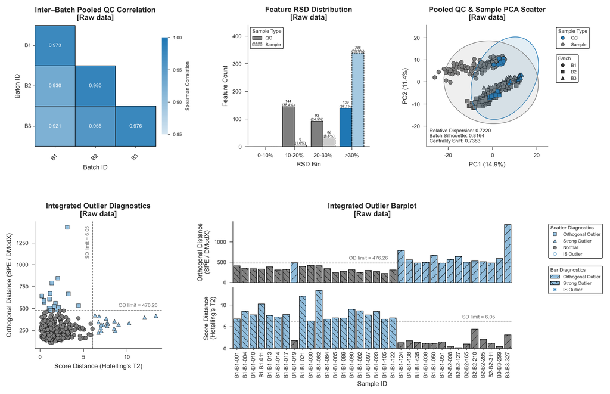

```
2026-08-19 14:42:13.442 | INFO     | runner:render:272 - Assessor summary dashboard saved as: tutorial_output\QA_01_Raw_Data\QA_Summary_Dashboard.svg
2026-08-19 14:42:13.442 | SUCCESS  | runner:render:273 - Data quality assessment completed.
2026-08-19 14:42:13.443 | SUCCESS  | timing:wrapped:27 - Execution time of "run_assessment": 7.796 seconds.
2026-08-19 14:42:13.442 | SUCCESS  | runner:render:273 - Data quality assessment completed.
2026-08-19 14:42:13.443 | SUCCESS  | timing:wrapped:27 - Execution time of "run_assessment": 7.796 seconds.
```

```python
logger.info("QA-Step 01: Quality Assessment of Raw Data...")

qa_step1_dir = os.path.join(OUTPUT_DIR, "QA_01_Raw_Data")
qa_raw_engine = MetaboIntAssessor(data=raw_data, pipeline_params=params)
qa_raw_result = qa_raw_engine.run_assessment(output_dir=qa_step1_dir)
assessments["raw_dataset"] = qa_raw_result
```

## Step 02: Missing Value Classification & Filtering

This call performs two dependent computations. It first screens only QC and Actual samples for sample-level missingness, leaving Blank and other non-target types intact. It then calculates global, QC, and biological-group missingness to classify features as MAR, MNAR, or INVALID. Group and QC rescue rules retain plausible sparse signals, and both attrition tables and labels are carried in the processing `StageResult`.

```
2026-08-19 14:42:13.471 | INFO     | __main__:<module>:1 - Step 02: High-Missing Value Feature Filtering...
```

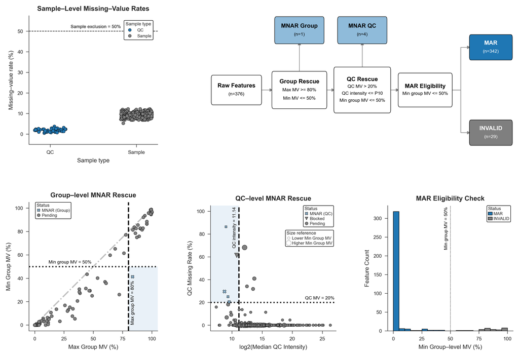

```
2026-08-19 14:42:16.154 | INFO     | runner:render:109 - High-MV Filter summary dashboard saved as: tutorial_output\02_MV_Filtered\MV_Classification_Dashboard.svg
2026-08-19 14:42:16.155 | SUCCESS  | runner:render:110 - High-missing value feature filtering completed.
2026-08-19 14:42:16.155 | SUCCESS  | timing:wrapped:27 - Execution time of "run_mv_filtering": 2.682 seconds.
2026-08-19 14:42:16.155 | SUCCESS  | runner:render:110 - High-missing value feature filtering completed.
2026-08-19 14:42:16.155 | SUCCESS  | timing:wrapped:27 - Execution time of "run_mv_filtering": 2.682 seconds.
```

```python
logger.info("Step 02: High-Missing Value Feature Filtering...")

step2_dir = os.path.join(OUTPUT_DIR, "02_MV_Filtered")
fltr_mv_engine = MetaboIntFilter(data=raw_data, pipeline_params=params)
mv_filter_result = fltr_mv_engine.run_mv_filtering(output_dir=step2_dir)
mv_filter_data = mv_filter_result.data
stage_results["high_mv_feature_filtering"] = mv_filter_result
stage_tables["high_mv_filtered"] = mv_filter_data
```

### QA-Step 02: Quality Assessment of High-MV Filtered Data

Compares the post-filter matrix with the raw baseline to reveal the effect of sample attrition and MAR/MNAR routing on QC consistency, RSD, sample structure, and reference-feature behaviour. The filtering labels and attrition tables remain in the processing result.

```
2026-08-19 14:42:16.181 | INFO     | __main__:<module>:1 - QA-Step 02: Quality Assessment of High-MV Filtered Data...
```

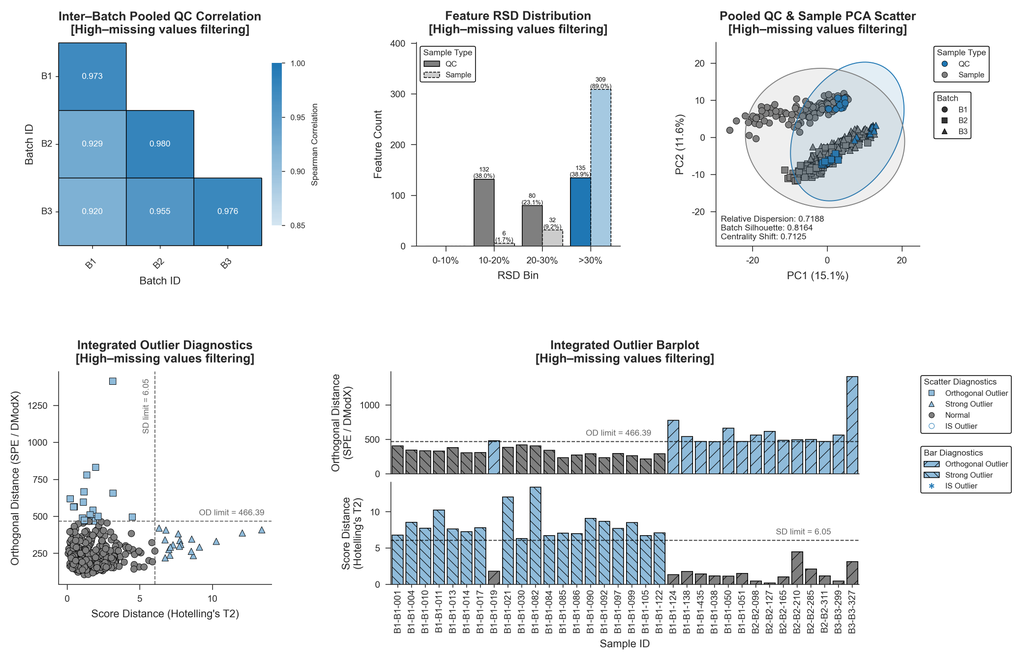

```
2026-08-19 14:42:23.906 | INFO     | runner:render:272 - Assessor summary dashboard saved as: tutorial_output\QA_02_MV_Filtered\QA_Summary_Dashboard.svg
2026-08-19 14:42:23.907 | SUCCESS  | runner:render:273 - Data quality assessment completed.
2026-08-19 14:42:23.907 | SUCCESS  | timing:wrapped:27 - Execution time of "run_assessment": 7.725 seconds.
2026-08-19 14:42:23.907 | SUCCESS  | runner:render:273 - Data quality assessment completed.
2026-08-19 14:42:23.907 | SUCCESS  | timing:wrapped:27 - Execution time of "run_assessment": 7.725 seconds.
```

```python
logger.info("QA-Step 02: Quality Assessment of High-MV Filtered Data...")

qa_step2_dir = os.path.join(OUTPUT_DIR, "QA_02_MV_Filtered")
qa_mv_filter_engine = MetaboIntAssessor(
    data=mv_filter_data, pipeline_params=params)
qa_mv_filter_result = qa_mv_filter_engine.run_assessment(
    output_dir=qa_step2_dir)
assessments["high_mv_feature_filtering"] = qa_mv_filter_result
```

## Step 03: Signal Drift and Batch Effect Mitigation

Evaluates one configured QC-anchored or global method, or compares SERRF, RUV-III, WaveICA 2.0, standard/robust QC-RLSC, and QC-SVR in `Auto` mode using QC-RSD and sample-structure criteria. QC-RLSC, QC-SVR, and QC-RFSC fit feature-wise drift from QC samples; multi-batch runs also evaluate batch alignment where applicable. Only the selected method's stage matrices are propagated, while candidate metrics remain in the correction `StageResult`. Blanks are excluded from fitting where supported and receive frozen-model corrections in output.

```
2026-08-19 14:42:23.939 | INFO     | __main__:<module>:1 - Step 03: Signal Drift & Batch Effect Correction...
2026-08-19 14:42:23.943 | INFO     | analysis:transform_correction:670 - Blank policy: 24 Blank samples are excluded from model fitting where supported and retained as frozen-model corrections in output.
2026-08-19 14:42:23.944 | INFO     | analysis:transform_correction:701 - AUTO mode enabled. Evaluating multiple methods.
2026-08-19 14:42:23.944 | INFO     | analysis:_evaluate_correction_candidates:371 - --- Evaluating Method: SERRF ---
2026-08-19 14:42:23.947 | INFO     | analysis:_prepare_serrf_correlation_matrix:306 - Calculating Spearman correlation on features...
2026-08-19 14:42:23.953 | INFO     | serrf:fit_transform:169 - Initializing High-Performance Hybrid SERRF Corrector...
```

```
2026-08-19 14:42:41.034 | INFO     | analysis:_evaluate_correction_candidates:581 - SERRF Eval QC RSD: 10.15%
2026-08-19 14:42:41.034 | INFO     | analysis:_evaluate_correction_candidates:371 - --- Evaluating Method: RUV-III ---
2026-08-19 14:42:41.043 | INFO     | analysis:_prepare_ruv_control_features:345 - RUV-III Control Features: 20 total (5 predefined, 17 empirical).
2026-08-19 14:42:41.044 | INFO     | ruv:fit_transform:49 - Executing RUV-III (k=5)...
2026-08-19 14:42:41.046 | WARNING  | ruv:fit_transform:75 - NaNs detected. Applying non-Blank median imputation...
2026-08-19 14:42:41.290 | INFO     | analysis:_evaluate_correction_candidates:581 - RUV-III Eval QC RSD: 11.09%
2026-08-19 14:42:41.291 | INFO     | analysis:_evaluate_correction_candidates:371 - --- Evaluating Method: WaveICA 2.0 ---
2026-08-19 14:42:41.292 | INFO     | waveica:fit_transform:504 - Executing WaveICA 2.0 correction...
2026-08-19 14:42:41.658 | INFO     | waveica:fit_transform:562 - WaveICA 2.0 Blank policy: 24 Blank samples received frozen artifact predictions (4172 proxy fallback cells; 204 source boundary fallbacks).
2026-08-19 14:42:41.845 | INFO     | analysis:_evaluate_correction_candidates:581 - WaveICA 2.0 Eval QC RSD: 18.56%
2026-08-19 14:42:41.846 | INFO     | analysis:_evaluate_correction_candidates:371 - --- Evaluating Method: QC-RLSC ---
2026-08-19 14:42:41.846 | INFO     | regression:fit_transform:79 - Phase 1: Executing Intra-batch drift correction with QC-RLSC...
2026-08-19 14:42:46.993 | INFO     | regression:fit_transform:281 - Phase 2: Executing Inter-batch median alignment...
2026-08-19 14:42:47.566 | INFO     | analysis:_evaluate_correction_candidates:581 - QC-RLSC Eval QC RSD: 13.08%
2026-08-19 14:42:47.567 | INFO     | analysis:_evaluate_correction_candidates:371 - --- Evaluating Method: robust QC-RLSC ---
2026-08-19 14:42:47.567 | INFO     | regression:fit_transform:79 - Phase 1: Executing Intra-batch drift correction with QC-RLSC...
2026-08-19 14:42:47.716 | INFO     | regression:fit_transform:281 - Phase 2: Executing Inter-batch median alignment...
2026-08-19 14:42:48.298 | INFO     | analysis:_evaluate_correction_candidates:581 - robust QC-RLSC Eval QC RSD: 13.50%
2026-08-19 14:42:48.298 | INFO     | analysis:_evaluate_correction_candidates:371 - --- Evaluating Method: QC-SVR ---
2026-08-19 14:42:48.299 | INFO     | regression:fit_transform:79 - Phase 1: Executing Intra-batch drift correction with QC-SVR...
```

```
2026-08-19 14:42:51.558 | INFO     | regression:fit_transform:281 - Phase 2: Executing Inter-batch median alignment...
2026-08-19 14:42:52.126 | INFO     | analysis:_evaluate_correction_candidates:581 - QC-SVR Eval QC RSD: 13.83%
2026-08-19 14:42:52.129 | SUCCESS  | analysis:transform_correction:737 - Auto selection: SERRF is optimal (score = 0.663, Eval QC RSD = 10.15%).
2026-08-19 14:42:52.216 | INFO     | runner:render:71 - Assembling correction diagnostic dashboard...
```

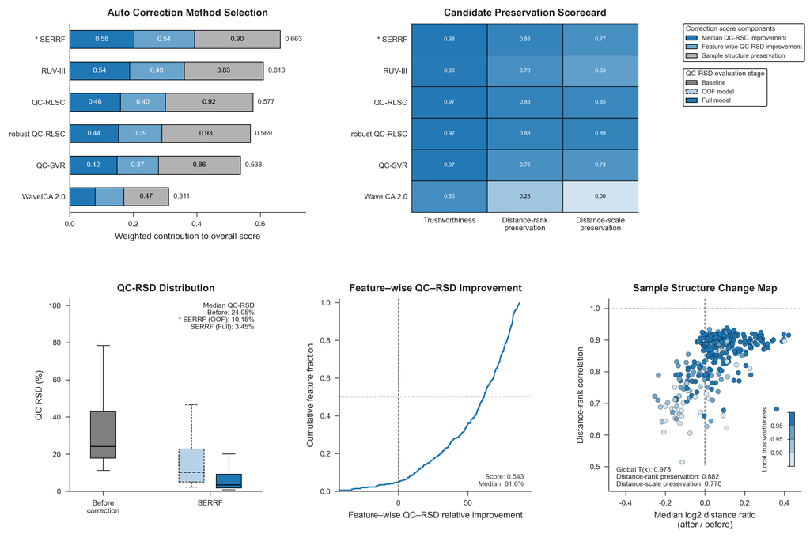

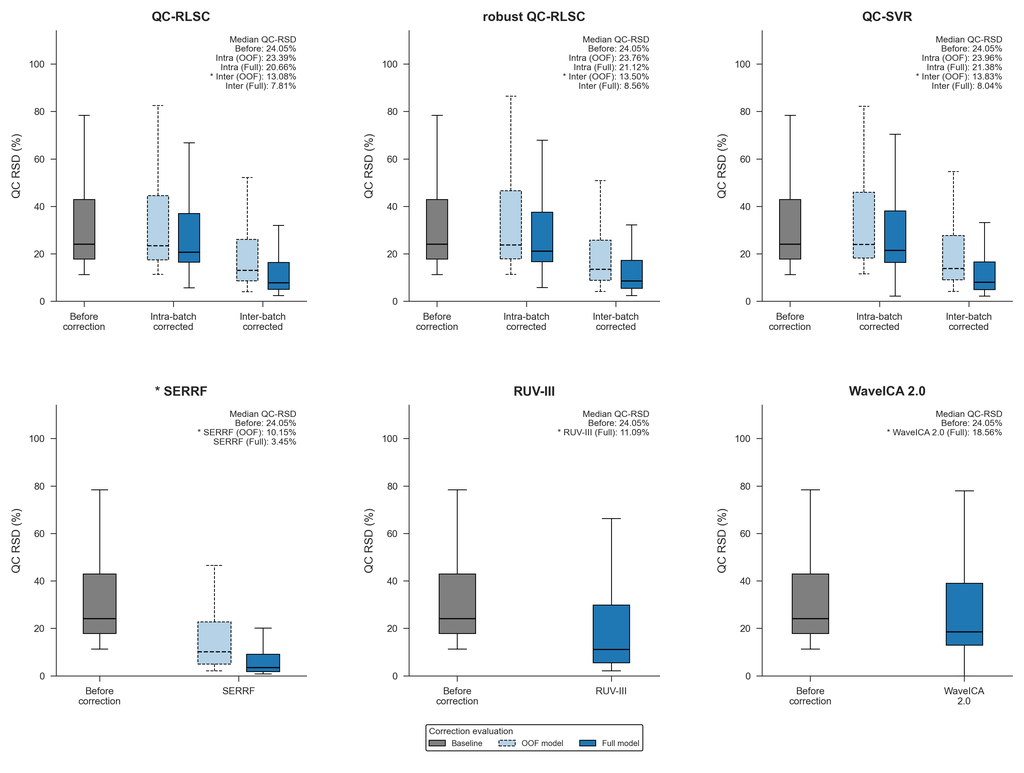

```
2026-08-19 14:43:11.988 | INFO     | runner:render:103 - Correction candidate dashboard saved as: tutorial_output\03_Corrected_Data\Correction_Candidate_Dashboard_SERRF.svg
2026-08-19 14:43:11.989 | INFO     | runner:_render_internal_standards:135 - Generating IS plots for SERRF...
2026-08-19 14:43:11.989 | INFO     | runner:_render_internal_standards:135 - Generating IS plots for SERRF...
2026-08-19 14:43:15.107 | INFO     | runner:_render_internal_standards:156 - Bypassing IS baseline prediction for SERRF.
2026-08-19 14:43:15.108 | SUCCESS  | runner:render:107 - Signal drift correction (SERRF) completed.
2026-08-19 14:43:15.108 | SUCCESS  | timing:wrapped:27 - Execution time of "run_signal_correction": 51.167 seconds.
```

```python
logger.info("Step 03: Signal Drift & Batch Effect Correction...")

step3_dir = os.path.join(OUTPUT_DIR, "03_Corrected_Data")
sc_engine = MetaboIntCorrector(data=mv_filter_data, pipeline_params=params)
correction_result = sc_engine.run_signal_correction(output_dir=step3_dir)
corrected_stages = correction_result.data

final_corr_data = list(corrected_stages.values())[-1]
stage_results["signal_correction"] = correction_result
for stage_name, stage_data in corrected_stages.items():
    stage_tables[f"corrected/{stage_name}"] = stage_data
```

### QA-Step 03: Quality Assessment of Signal Corrected Data

Assesses every selected correction stage, rather than every `Auto` candidate, to show whether drift and batch effects improved while checking for unintended changes to sample structure and reference-feature behaviour.

```
2026-08-19 14:43:15.137 | INFO     | __main__:<module>:1 - QA-Step 03: Quality Assessment of Signal Corrected Data...
2026-08-19 14:43:15.138 | INFO     | __main__:<module>:7 - QA-Step 03: Quality Assessment for corrected stage 'SERRF'...
```

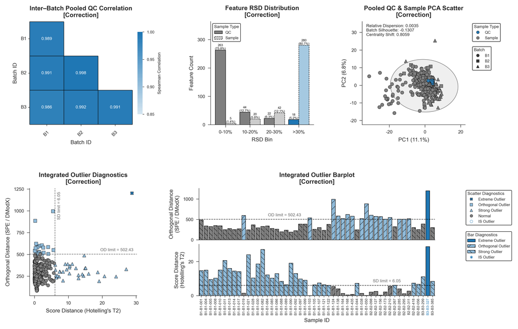

```
2026-08-19 14:43:23.433 | INFO     | runner:render:272 - Assessor summary dashboard saved as: tutorial_output\QA_03_Corrected_Data\SERRF\QA_Summary_Dashboard.svg
2026-08-19 14:43:23.434 | SUCCESS  | runner:render:273 - Data quality assessment completed.
2026-08-19 14:43:23.435 | SUCCESS  | timing:wrapped:27 - Execution time of "run_assessment": 8.295 seconds.
2026-08-19 14:43:23.434 | SUCCESS  | runner:render:273 - Data quality assessment completed.
2026-08-19 14:43:23.435 | SUCCESS  | timing:wrapped:27 - Execution time of "run_assessment": 8.295 seconds.
```

```python
logger.info("QA-Step 03: Quality Assessment of Signal Corrected Data...")

qa_step3_dir = os.path.join(OUTPUT_DIR, "QA_03_Corrected_Data")

qa_results_dict = {}
for stage_name, stage_data in corrected_stages.items():
    logger.info(
        f"QA-Step 03: Quality Assessment for corrected stage "
        f"'{stage_name}'..."
    )
    qa_corr_engine = MetaboIntAssessor(data=stage_data, pipeline_params=params)
    qa_corr_result = qa_corr_engine.run_assessment(
        output_dir=os.path.join(qa_step3_dir, stage_name))
    qa_results_dict[stage_name] = qa_corr_result
    assessments[f"signal_correction/{stage_name}"] = qa_corr_result
```

## Step 04: Low-Quality Feature Filtering

Removes features dominated by background using the mean Blank/QC ratio, then removes technically irreproducible MAR features using pooled-QC RSD. Features labeled MNAR in Step 02 are exempt from the RSD screen so expected trace-level variability does not discard low-abundance signals.

```
2026-08-19 14:43:23.463 | INFO     | __main__:<module>:1 - Step 04: Low-Quality Feature Filtering...
2026-08-19 14:43:23.467 | INFO     | analysis:transform_quality_filtering:669 - Features before filtering: 347
2026-08-19 14:43:23.475 | INFO     | analysis:transform_quality_filtering:687 - Features after Blank/QC check: 268
2026-08-19 14:43:23.483 | INFO     | analysis:transform_quality_filtering:708 - Features after QC RSD check: 256
2026-08-19 14:43:23.571 | INFO     | runner:export:161 - Data after low-quality features filtering saved as: tutorial_output\04_Quality_Filtered\Filtered_Data_Low-quality_Features.csv
```

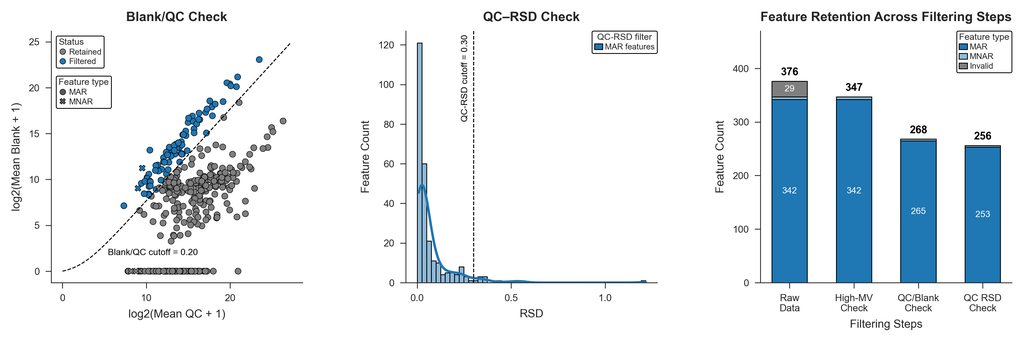

```
2026-08-19 14:43:30.378 | INFO     | runner:render:182 - Low-quality Filter summary dashboard saved as: tutorial_output\04_Quality_Filtered\Low-quality_Filtering_Dashboard.svg
2026-08-19 14:43:30.379 | SUCCESS  | runner:render:190 - Low-quality features filtering completed.
2026-08-19 14:43:30.379 | SUCCESS  | timing:wrapped:27 - Execution time of "run_quality_filtering": 6.912 seconds.
2026-08-19 14:43:30.379 | SUCCESS  | runner:render:190 - Low-quality features filtering completed.
2026-08-19 14:43:30.379 | SUCCESS  | timing:wrapped:27 - Execution time of "run_quality_filtering": 6.912 seconds.
```

```python
logger.info("Step 04: Low-Quality Feature Filtering...")

step4_dir = os.path.join(OUTPUT_DIR, "04_Quality_Filtered")
fltr_low_quality_engine = MetaboIntFilter(
    data=final_corr_data, pipeline_params=params)
low_quality_filter_result = fltr_low_quality_engine.run_quality_filtering(
    output_dir=step4_dir
)
low_quality_filter_data = low_quality_filter_result.data
stage_results["low_quality_feature_filtering"] = (
    low_quality_filter_result
)
stage_tables["quality_filtered"] = low_quality_filter_data
```

### QA-Step 04: Quality Assessment of Low-Quality Filtered Data

Checks whether Blank/QC and RSD-based feature removal changed QC consistency or sample structure before imputation. The retained-feature set and removal reasons are documented by the preceding filtering `StageResult`.

```
2026-08-19 14:43:30.412 | INFO     | __main__:<module>:1 - QA-Step 04: Quality Assessment of Low-Quality Filtered Data...
```

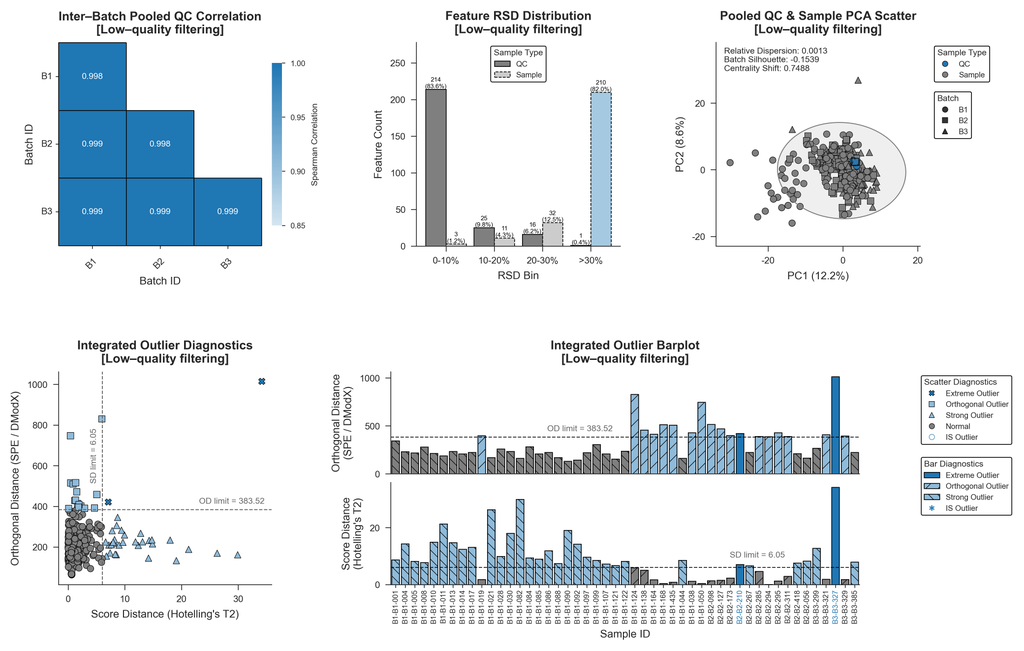

```
2026-08-19 14:43:38.754 | INFO     | runner:render:272 - Assessor summary dashboard saved as: tutorial_output\QA_04_Quality_Filtered\QA_Summary_Dashboard.svg
2026-08-19 14:43:38.755 | SUCCESS  | runner:render:273 - Data quality assessment completed.
2026-08-19 14:43:38.755 | SUCCESS  | timing:wrapped:27 - Execution time of "run_assessment": 8.341 seconds.
2026-08-19 14:43:38.755 | SUCCESS  | runner:render:273 - Data quality assessment completed.
2026-08-19 14:43:38.755 | SUCCESS  | timing:wrapped:27 - Execution time of "run_assessment": 8.341 seconds.
```

```python
logger.info("QA-Step 04: Quality Assessment of Low-Quality Filtered Data...")

qa_step4_dir = os.path.join(OUTPUT_DIR, "QA_04_Quality_Filtered")
qa_low_quality_filter_engine = MetaboIntAssessor(
    data=low_quality_filter_data, pipeline_params=params
)
qa_low_quality_filter_result = (
    qa_low_quality_filter_engine.run_assessment(output_dir=qa_step4_dir)
)
assessments["low_quality_feature_filtering"] = (
    qa_low_quality_filter_result
)
```

## Step 05: Missing Value Imputation

Uses the MAR/MNAR labels from Step 02 and imputes only non-Blank samples. MNAR features use QRILC or row-, column-, or global LOD-fraction constants. MAR features use KNN, LLS, BPCA, MinProb, Median, or `Auto`; Auto benchmarks MAR candidates with stratified masking, reconstruction/distribution metrics, and sample-structure preservation before applying the selected method. Blank columns are preserved without imputation, and the stage records a skipped result when no target values are missing.

```
2026-08-19 14:43:38.784 | INFO     | __main__:<module>:1 - Step 05: Missing Value Imputation...
2026-08-19 14:43:38.791 | INFO     | analysis:transform_imputation:1420 - Hybrid Imputation Engine Initialized. MAR: Auto (Evaluating KNN=5, LLS (K=15), BPCA (PCs=2), MinProb, Median) | MNAR: QRILC | Sim_Mask: 0.05
2026-08-19 14:43:38.797 | INFO     | analysis:transform_imputation:1435 - Applying QRILC to 3 MNAR features.
2026-08-19 14:43:39.715 | INFO     | analysis:_select_best_imputation_method:1149 - Simulating "KNN" on MAR subset...
2026-08-19 14:43:40.179 | INFO     | analysis:_select_best_imputation_method:1149 - Simulating "MinProb" on MAR subset...
2026-08-19 14:43:40.997 | INFO     | analysis:_select_best_imputation_method:1149 - Simulating "QRILC" on MAR subset...
2026-08-19 14:43:41.572 | INFO     | analysis:_select_best_imputation_method:1149 - Simulating "Median" on MAR subset...
2026-08-19 14:43:42.198 | INFO     | analysis:_select_best_imputation_method:1149 - Simulating "LLS" on MAR subset...
2026-08-19 14:43:42.594 | INFO     | analysis:_select_best_imputation_method:1149 - Simulating "BPCA" on MAR subset...
2026-08-19 14:43:43.260 | INFO     | analysis:_select_best_imputation_method:1208 - Optimal MAR algorithm selected: LLS (score=0.888)
2026-08-19 14:43:43.260 | INFO     | analysis:transform_imputation:1479 - Executing isolated 'LLS' on MAR features.
2026-08-19 14:43:43.339 | INFO     | analysis:transform_imputation:1581 - Calculating imputation-related metrics...
2026-08-19 14:43:43.557 | INFO     | runner:render:45 - Generating diagnostic plots for imputation...
```

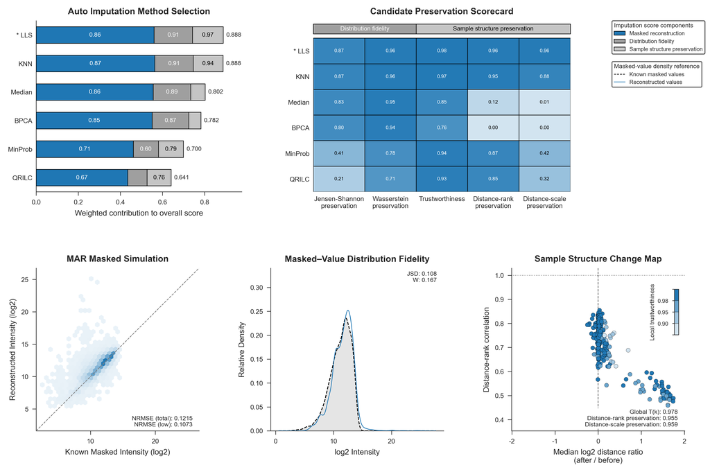

```
2026-08-19 14:43:58.414 | INFO     | runner:render:78 - Imputation dashboard saved as: tutorial_output\05_Imputation\Imputation_Dashboard_LLS.svg
```

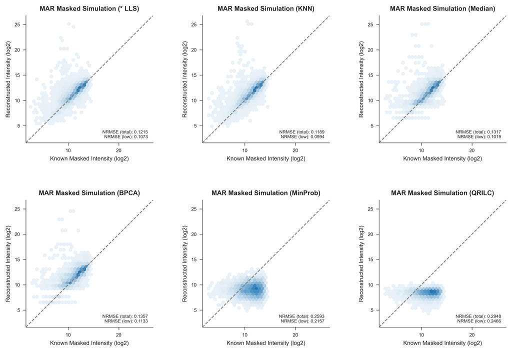

```
2026-08-19 14:44:01.419 | INFO     | runner:render:97 - Imputer candidate NRMSE grid saved as: tutorial_output\05_Imputation\Imputation_Candidate_Dashboard_LLS.svg
2026-08-19 14:44:01.420 | SUCCESS  | analysis:run_imputation:1628 - Missing value imputation completed successfully.
2026-08-19 14:44:01.420 | SUCCESS  | timing:wrapped:27 - Execution time of "run_imputation": 22.635 seconds.
2026-08-19 14:44:01.420 | SUCCESS  | analysis:run_imputation:1628 - Missing value imputation completed successfully.
2026-08-19 14:44:01.420 | SUCCESS  | timing:wrapped:27 - Execution time of "run_imputation": 22.635 seconds.
```

```python
logger.info("Step 05: Missing Value Imputation...")

step5_dir = os.path.join(OUTPUT_DIR, "05_Imputation")
imp_engine = MetaboIntImputer(
    data=low_quality_filter_data, pipeline_params=params)
imputation_result = imp_engine.run_imputation(output_dir=step5_dir)
imputed_data = imputation_result.data
stage_results["missing_value_imputation"] = imputation_result
stage_tables["imputed"] = imputed_data
```

### QA-Step 05: Quality Assessment of Imputed Data

Checks whether completing missing values introduced distributional, QC-consistency, or sample-structure shifts. The imputation `StageResult`, rather than this QA checkpoint, carries the selected method and candidate benchmarks.

```
2026-08-19 14:44:01.456 | INFO     | __main__:<module>:1 - QA-Step 05: Quality Assessment of Imputed Data...
```

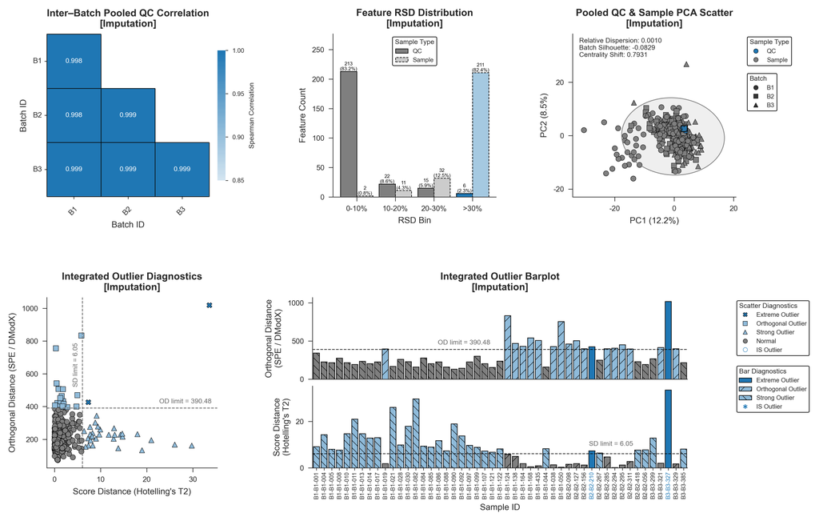

```
2026-08-19 14:44:09.553 | INFO     | runner:render:272 - Assessor summary dashboard saved as: tutorial_output\QA_05_Imputed_Data\QA_Summary_Dashboard.svg
2026-08-19 14:44:09.554 | SUCCESS  | runner:render:273 - Data quality assessment completed.
2026-08-19 14:44:09.554 | SUCCESS  | timing:wrapped:27 - Execution time of "run_assessment": 8.096 seconds.
2026-08-19 14:44:09.554 | SUCCESS  | runner:render:273 - Data quality assessment completed.
2026-08-19 14:44:09.554 | SUCCESS  | timing:wrapped:27 - Execution time of "run_assessment": 8.096 seconds.
```

```python
logger.info("QA-Step 05: Quality Assessment of Imputed Data...")

qa_step5_dir = os.path.join(OUTPUT_DIR, "QA_05_Imputed_Data")
qa_imp_engine = MetaboIntAssessor(data=imputed_data, pipeline_params=params)
qa_imp_result = qa_imp_engine.run_assessment(output_dir=qa_step5_dir)
assessments["missing_value_imputation"] = qa_imp_result
```

## Step 06: Data Normalization

Applies robust-log-only, TIC, Median, PQN, MDFC, Quantile, or VSN normalization. TIC/Median/PQN/MDFC use robust Log2 afterward, Quantile aligns robust-logged distributions, and VSN uses an intrinsic generalized log. In `Auto`, fixed candidates are scored with QC RLE, QC variance/structure, and sample-structure guardrails; blank samples are excluded from the normalized output.

```
2026-08-19 14:44:09.585 | INFO     | __main__:<module>:1 - Step 06: Data Normalization...
2026-08-19 14:44:09.590 | INFO     | runner:compute:32 - Permanently dropping 24 Blank samples.
2026-08-19 14:44:09.591 | INFO     | runner:compute:33 - Applying Normalization | Method: Auto
2026-08-19 14:44:09.600 | INFO     | analysis:_select_auto_normalization:1217 - Auto normalization evaluates fixed strategies on a common log-like view using QC RLE, QC variance stabilization, QC structure, and sample structure criteria.
2026-08-19 14:44:09.601 | INFO     | analysis:_select_auto_normalization:1229 - Evaluating Auto normalization candidate: ROBUST_LOG_ONLY (log_transform=True).
2026-08-19 14:44:09.959 | INFO     | analysis:_select_auto_normalization:1229 - Evaluating Auto normalization candidate: TIC (log_transform=True).
2026-08-19 14:44:10.318 | INFO     | analysis:_select_auto_normalization:1229 - Evaluating Auto normalization candidate: MEDIAN (log_transform=True).
2026-08-19 14:44:10.672 | INFO     | analysis:_select_auto_normalization:1229 - Evaluating Auto normalization candidate: PQN (log_transform=True).
2026-08-19 14:44:11.024 | INFO     | analysis:_select_auto_normalization:1229 - Evaluating Auto normalization candidate: MDFC (log_transform=True).
2026-08-19 14:44:11.029 | INFO     | analysis:calc_mdfc_normalization:1092 - Executing chunked parallel MDFC (backend='loky', cores=8, chunks=32)...
2026-08-19 14:44:13.920 | INFO     | analysis:_select_auto_normalization:1229 - Evaluating Auto normalization candidate: QUANTILE (log_transform=True).
2026-08-19 14:44:14.306 | INFO     | analysis:_select_auto_normalization:1229 - Evaluating Auto normalization candidate: VSN (log_transform=False).
2026-08-19 14:44:40.374 | INFO     | analysis:_select_auto_normalization:1292 - Auto normalization candidate scores: ROBUST_LOG_ONLY=0.500, TIC=0.625, MEDIAN=0.525, PQN=0.712, MDFC=0.663, QUANTILE=0.421, VSN=0.512
2026-08-19 14:44:40.375 | INFO     | analysis:_select_auto_normalization:1302 - Auto normalization selected PQN (score=0.712, margin=0.050).
2026-08-19 14:44:40.445 | INFO     | runner:export:79 - Auto normalization summary saved as: tutorial_output\06_Normalized_Data\Normalization_Auto_Summary.csv
2026-08-19 14:44:40.445 | INFO     | runner:render:83 - Generating diagnostic plots for normalization...
```

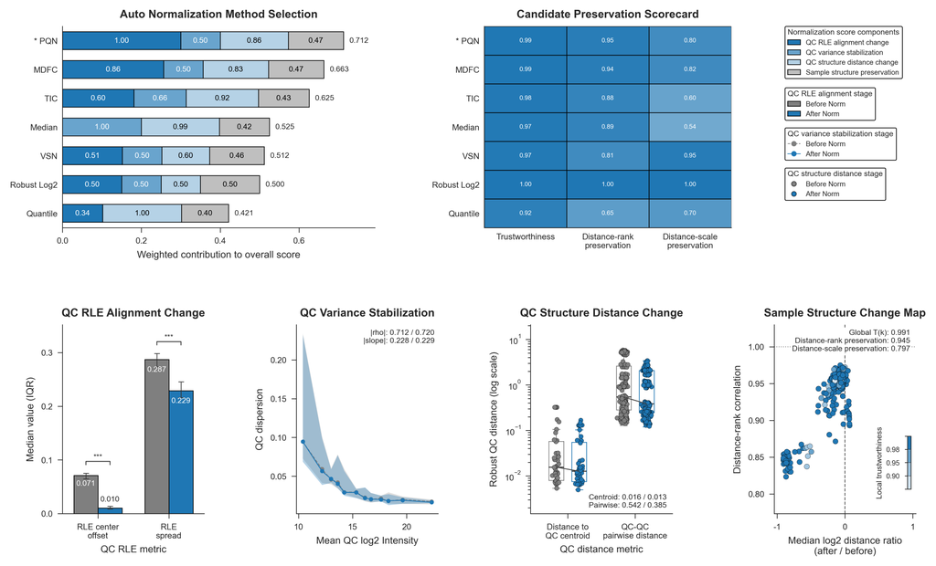

```
2026-08-19 14:44:45.407 | INFO     | runner:render:96 - Normalization summary dashboard saved as: tutorial_output\06_Normalized_Data\Normalization_Dashboard_PQN_Log2.svg
2026-08-19 14:44:45.408 | SUCCESS  | analysis:run_normalization:1426 - Data normalization completed successfully.
2026-08-19 14:44:45.408 | SUCCESS  | analysis:run_normalization:1426 - Data normalization completed successfully.
```

```python
logger.info("Step 06: Data Normalization...")

step6_dir = os.path.join(OUTPUT_DIR, "06_Normalized_Data")
norm_engine = MetaboIntNormalizer(imputed_data, pipeline_params=params)
normalization_result = norm_engine.run_normalization(output_dir=step6_dir)
normalized_data = normalization_result.data
stage_results["normalization"] = normalization_result
stage_tables["normalized"] = normalized_data
```

### QA-Step 06: Quality Assessment on Normalized Data

Checks whether normalization reduced residual scale and batch effects while preserving sample structure and reference-feature behaviour.

```
2026-08-19 14:44:45.437 | INFO     | __main__:<module>:1 - QA-Step 06: Quality Assessment of Normalized Data...
```

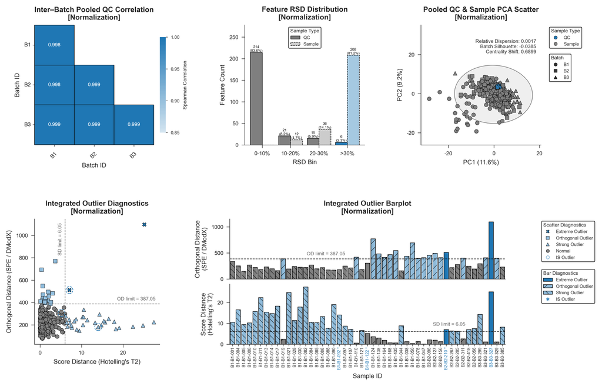

```
2026-08-19 14:44:53.009 | INFO     | runner:render:272 - Assessor summary dashboard saved as: tutorial_output\QA_06_Norm_Data\QA_Summary_Dashboard.svg
2026-08-19 14:44:53.010 | SUCCESS  | runner:render:273 - Data quality assessment completed.
2026-08-19 14:44:53.011 | SUCCESS  | timing:wrapped:27 - Execution time of "run_assessment": 7.572 seconds.
2026-08-19 14:44:53.010 | SUCCESS  | runner:render:273 - Data quality assessment completed.
2026-08-19 14:44:53.011 | SUCCESS  | timing:wrapped:27 - Execution time of "run_assessment": 7.572 seconds.
```

```python
logger.info("QA-Step 06: Quality Assessment of Normalized Data...")

qa_step6_dir = os.path.join(OUTPUT_DIR, "QA_06_Norm_Data")
qa_norm_engine = MetaboIntAssessor(data=normalized_data, pipeline_params=params)
qa_norm_result = qa_norm_engine.run_assessment(output_dir=qa_step6_dir)
assessments["normalization"] = qa_norm_result
```

## Step 07: Sequential Audit Report Compilation

Consolidates stage metrics, QA metrics, tracking tables, and visual assets into a report workspace, renders comprehensive and brief Markdown reports, and exports the configured PDF representation for an auditable record of the workflow.

```
2026-08-19 14:44:53.040 | INFO     | __main__:<module>:1 - Step 07: Sequential Audit Report Compilation...
2026-08-19 14:44:53.042 | INFO     | utils:compile_assessor_report:487 - Multi-batch design detected. Assembling Batch Grid.
```

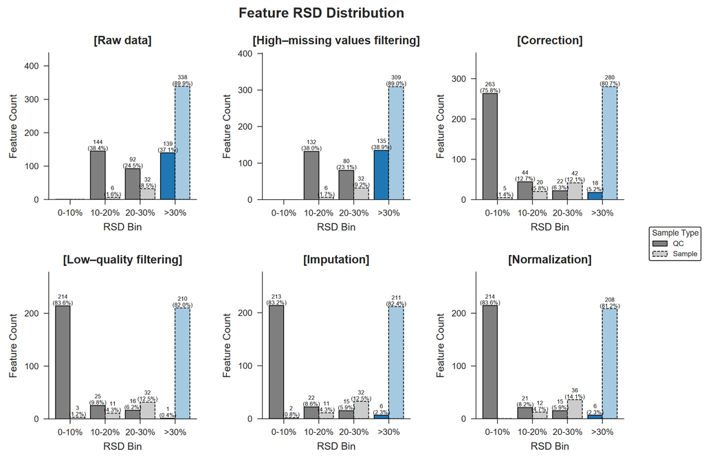

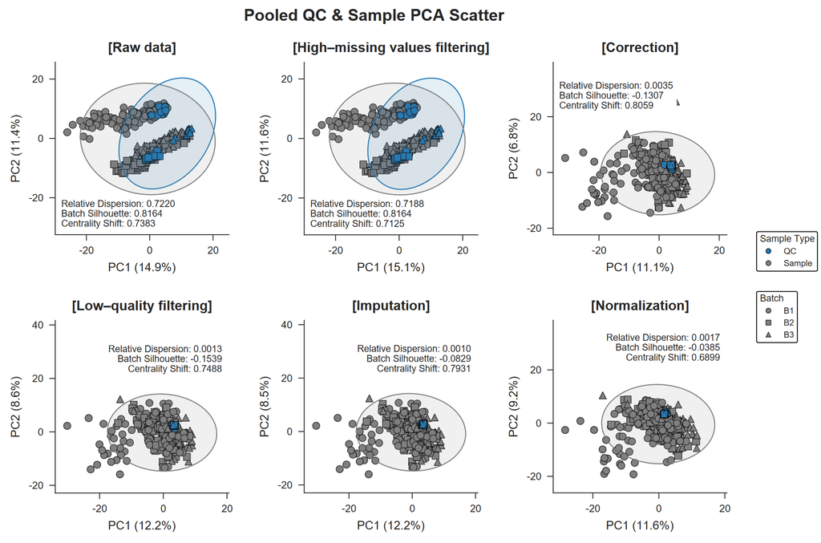

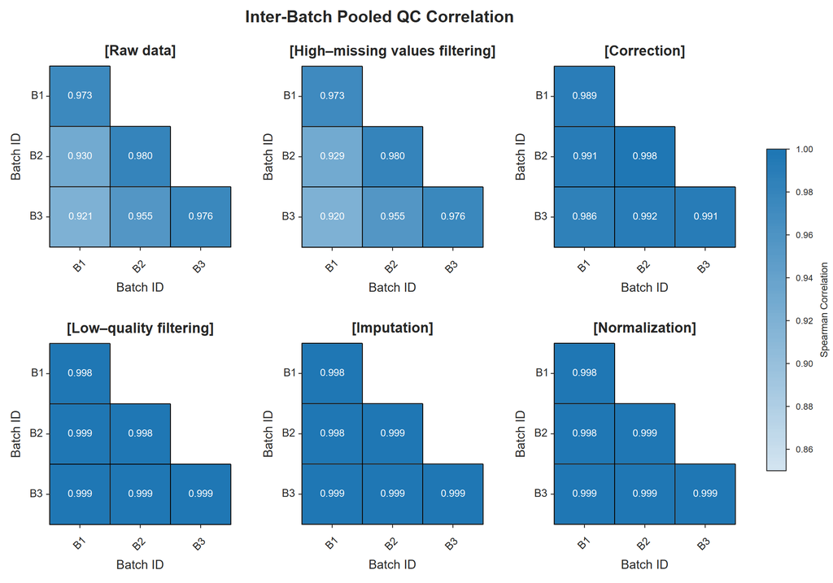

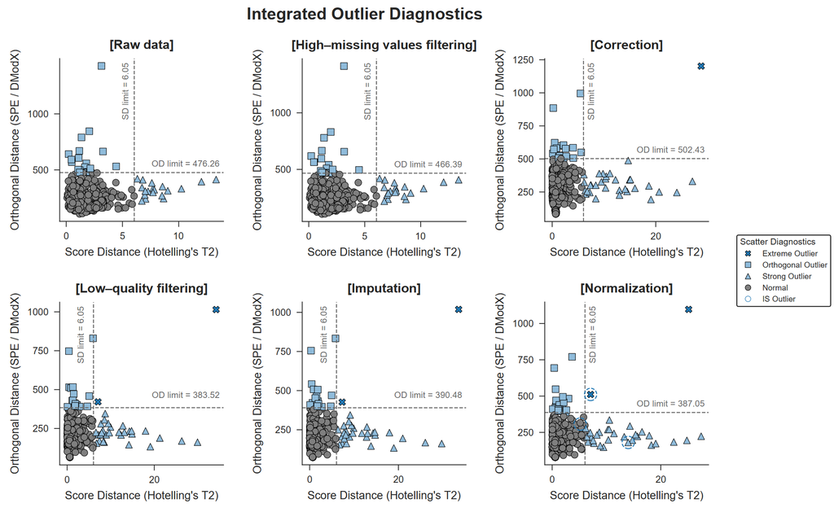

```
2026-08-19 14:44:54.515 | SUCCESS  | utils:compile_assessor_report:595 - Report SVG assets compiled at: tutorial_output\07_Report_Summary\assets
2026-08-19 14:44:54.516 | INFO     | __main__:<module>:56 - Initializing narrative reporter at workspace: .\tutorial_output
2026-08-19 14:44:54.520 | INFO     | utils:generate_markdown:1763 - Generating COMPREHENSIVE narrative report...
2026-08-19 14:44:54.516 | INFO     | __main__:<module>:56 - Initializing narrative reporter at workspace: .\tutorial_output
2026-08-19 14:44:54.520 | INFO     | utils:generate_markdown:1763 - Generating COMPREHENSIVE narrative report...
2026-08-19 14:44:54.561 | SUCCESS  | utils:generate_markdown:1773 - Comprehensive report generated: tutorial_output\07_Report_Summary\Report_Comprehensive.md
2026-08-19 14:44:54.561 | INFO     | utils:generate_markdown:1763 - Generating BRIEF narrative report...
2026-08-19 14:44:54.577 | SUCCESS  | utils:generate_markdown:1773 - Brief report generated: tutorial_output\07_Report_Summary\Report_Brief.md
2026-08-19 14:44:54.737 | INFO     | utils:export_report:1929 - --- Exporting PDF for: Report_Comprehensive.md ---
2026-08-19 14:44:54.738 | INFO     | utils:_render_weasyprint:1847 - Attempting PDF export via WeasyPrint...
2026-08-19 14:45:00.670 | SUCCESS  | utils:_render_weasyprint:1873 - PDF generated: tutorial_output\07_Report_Summary\Report_Comprehensive.pdf
2026-08-19 14:45:00.671 | SUCCESS  | utils:export_report:1957 - [Report_Comprehensive.md] completed using WeasyPrint.
2026-08-19 14:45:00.672 | INFO     | utils:export_report:1929 - --- Exporting PDF for: Report_Brief.md ---
2026-08-19 14:45:00.672 | INFO     | utils:_render_weasyprint:1847 - Attempting PDF export via WeasyPrint...
2026-08-19 14:45:02.331 | SUCCESS  | utils:_render_weasyprint:1873 - PDF generated: tutorial_output\07_Report_Summary\Report_Brief.pdf
2026-08-19 14:45:02.332 | SUCCESS  | utils:export_report:1957 - [Report_Brief.md] completed using WeasyPrint.
2026-08-19 14:45:02.333 | SUCCESS  | __main__:<module>:75 - PI-METABOQC PIPELINE COMPLETED SUCCESSFULLY.
```

```python
logger.info("Step 07: Sequential Audit Report Compilation...")

REPORT_DIR = "07_Report_Summary"
# 1. Process Visual Assets
visual_rep = ru.VisualAssetReporter(base_dir=OUTPUT_DIR)
visual_rep.compile_assessor_report(
    report_folder=REPORT_DIR, is_multi_batch=is_multi_batch_flag
)

# 2. Dynamic QA Mapping
qa_corr_metrics = {}
stage_key_map = {
    "Intra-batch corrected": "intra_batch_correction",
    "Inter-batch corrected": "inter_batch_correction",
    "SERRF": "global_correction",
    "RUV-III": "global_correction",
    "WaveICA 2.0": "global_correction",
}

for stage_name, result in qa_results_dict.items():
    safe_key = stage_key_map.get(stage_name, "unknown_correction")
    qa_corr_metrics[safe_key] = result.metrics

# 3. Assemble Final Metrics
pipeline_metrics_objs = {
    "raw_dataset": stage_results["raw_dataset"].metrics,
    "high_mv_feature_filtering": stage_results[
        "high_mv_feature_filtering"
    ].metrics,
    "signal_correction": stage_results["signal_correction"].metrics,
    "low_quality_feature_filtering": stage_results[
        "low_quality_feature_filtering"
    ].metrics,
    "missing_value_imputation": stage_results[
        "missing_value_imputation"
    ].metrics,
    "normalization": stage_results["normalization"].metrics,
}

qa_metrics_objs = {
    "raw_dataset": assessments["raw_dataset"].metrics,
    "high_mv_feature_filtering": assessments[
        "high_mv_feature_filtering"
    ].metrics,
    **qa_corr_metrics,
    "low_quality_feature_filtering": assessments[
        "low_quality_feature_filtering"
    ].metrics,
    "missing_value_imputation": assessments[
        "missing_value_imputation"
    ].metrics,
    "normalization": assessments["normalization"].metrics,
}

# 4. Initialize reporter and generate ONE markdown file
logger.info(f"Initializing narrative reporter at workspace: {OUTPUT_DIR}")
md_reporter = ru.NarrativeStatsReporter(base_dir=OUTPUT_DIR)

report_input = ReportInput(
    pipeline_metrics=pipeline_metrics_objs,
    qa_metrics=qa_metrics_objs,
    metadata={
        "date": datetime.now().strftime("%Y-%m-%d %H:%M"),
        "version": pimqc.__version__,
        "mode": stage_results["raw_dataset"].metrics.get("mode", "N/A"),
        "is_multi_batch": raw_data.attrs["is_multi_batch"],
    },
    resolved_config=params,
)
md_reporter.generate_markdown(report_input, report_folder=REPORT_DIR)

success = md_reporter.export_report(pdf_engine="weasyprint")

if success:
    logger.success("PI-METABOQC PIPELINE COMPLETED SUCCESSFULLY.")
```